# MIE237

2016-04-08

## the analysis of designed experiments

## Formal definitions: factor, level

A *factor* is a controllable experimental condition.

A factor can take on two or more *levels*.

E.g., in a study of haul trucks "oil brand" could be a factor, with levels "Castrol", "Volvo", "Komatsu".

When experimental units are randomly assigned to levels of a factor and some output measure is observed, this is called a *designed experiment*. The formal model is typically written as (more on this later):\[ Y_{ij} = \mu_i + {\varepsilon}_{ij}\]

We've seen the case of \(i \in \{1, 2\}\)—such an experiment would be analyzed using a two-sample \(t\) procedure.

In reality any dataset with one categorical "input" variable and one numerical "output" variable will be analysed the same as a formally designed experiment.

## Typical dataset…

| Truck.ID | Oil | Viscosity |
| --- | --- | --- |
| HT 265 | Volvo | 25.5 |
| HT 372 | Castrol | 25.7 |
| HT 572 | Komatsu | 25.6 |
| HT 908 | Volvo | 24.7 |
| HT 201 | Castrol | 26.5 |
| HT 898 | Komatsu | 25.4 |
| HT 944 | Volvo | 24.4 |
| HT 660 | Castrol | 22.8 |
| HT 629 | Komatsu | 26.1 |
| HT 61 | Volvo | 25.0 |
| HT 205 | Castrol | 25.0 |
| HT 176 | Komatsu | 25.9 |

## One factor notation, models

"Balanced" case with equal sample size \(n\) for each of \(k\) levels for \(N = nk\) total.

| Levels: | 1 | 2 | … | i | … | k |
| --- | --- | --- | --- | --- | --- | --- |
|  | \(y_{11}\) | \(y_{21}\) | … | \(y_{i1}\) | … | \(y_{k1}\) |
|  | \(y_{12}\) | \(y_{22}\) | … | \(y_{i2}\) | … | \(y_{k2}\) |
|  | \(\vdots\) | \(\vdots\) |  | \(\vdots\) |  | \(\vdots\) |
|  | \(y_{1n}\) | \(y_{2n}\) | … | \(y_{in}\) | … | \(y_{kn}\) |
| Sample average: | \({\overline{y}}_{1\cdot}\) | \({\overline{y}}_{2\cdot}\) | … | \({\overline{y}}_{i\cdot}\) | … | \({\overline{y}}_{k\cdot}\) |

Grand overall average: \({\overline{y}}_{\cdot\cdot}\)

Models:\[y_{ij} = \mu_i + {\varepsilon}_{ij}, \qquad {\varepsilon}_{ij} \text{ i.i.d. } N(0, \sigma^2)\]\[y_{ij}= \mu + \alpha_i + {\varepsilon}_{ij}, \qquad \sum \alpha_i = 0 \qquad {\varepsilon}_{ij} \text{ i.i.d. } N(0, \sigma^2)\]

## The main question

In other words "is the variation among all the \(y_{ij}\) due to the factor variable, or just due to random chance?". The analysis even follows this logic.

The variation among the \(y_{ij}\) is quantified as (as usual?):

\[(N-1)\cdot s^2_y = \sum_{i=1}^k\sum_{j=1}^n \left(y_{ij} - {\overline{y}}_{\cdot\cdot}\right)^2\]

We will split this up into the "factor" part and the "random chance" part (like done in regression).

## "Analysis of Variance" - I

Build up from the inside out. For any \(i\) and \(j\) fixed:\[\begin{align}\left(y_{ij} - {\overline{y}}_{\cdot\cdot}\right)^2 &= \left(y_{ij} - {\overline{y}}_{i\cdot} + {\overline{y}}_{i\cdot} - {\overline{y}}_{\cdot\cdot}\right)^2\\ &=\left(y_{ij} - {\overline{y}}_{i\cdot}\right)^2 + \left({\overline{y}}_{i\cdot} - {\overline{y}}_{\cdot\cdot}\right)^2 + 2\left(y_{ij} - {\overline{y}}_{i\cdot}\right)\left({\overline{y}}_{i\cdot} - {\overline{y}}_{\cdot\cdot}\right) \end{align}\]

Next, sum from \(j=1\) to \(n\) to get:\[\sum_{j=1}^n \left(y_{ij} - {\overline{y}}_{\cdot\cdot}\right)^2 =\sum_{j=1}^n\left(y_{ij} - {\overline{y}}_{i\cdot}\right)^2 + \sum_{j=1}^n\left({\overline{y}}_{i\cdot} - {\overline{y}}_{\cdot\cdot}\right)^2 + 2\left({\overline{y}}_{i\cdot} - {\overline{y}}_{\cdot\cdot}\right)\sum_{j=1}^n\left(y_{ij} - {\overline{y}}_{i\cdot}\right)\]

Finally, sum from \(i=1\) to \(k\) and rearrange:\[\sum_{i=1}^k\sum_{j=1}^n \left(y_{ij} - {\overline{y}}_{\cdot\cdot}\right)^2 = \sum_{i=1}^kn\left({\overline{y}}_{i\cdot} - {\overline{y}}_{\cdot\cdot}\right)^2 + + \sum_{i=1}^k\sum_{j=1}^n\left(y_{ij} - {\overline{y}}_{i\cdot}\right)^2 \]

## (Note: unbalanced case)

Simply replace \(n\) with \(n_i\) (sample size for level \(i\))

## "Analysis of Variance" - II

Similar to the regression case:\[\begin{align}\sum_{i=1}^k\sum_{j=1}^n \left(y_{ij} - {\overline{y}}_{\cdot\cdot}\right)^2 &= \sum_{i=1}^kn\left({\overline{y}}_{i\cdot} - {\overline{y}}_{\cdot\cdot}\right)^2 + + \sum_{i=1}^k\sum_{j=1}^n\left(y_{ij} - {\overline{y}}_{i\cdot}\right)^2\\ SST \qquad &= \qquad SSA \qquad + \qquad SSE\\ \chi^2_{nk-1} \qquad &= \qquad \chi^2_{k-1} \qquad + \qquad \chi^2_{k(n-1)}\end{align}\]

Note that \(nk-1 = k - 1 + k(n-1)\), as expected.

Call:\[MSA = \frac{SSA}{k-1} \qquad \text{ and } \qquad MSE = \frac{SSE}{k(n-1)}\]

## "Analysis of Variance" - III

The analysis is based on:\[F = \frac{MSA}{MSE} \sim F_{k-1, k(n-1)}\]

For example, consider exercise 13.1 "tensile strength of rubber seals". \(k=6\) machines are compared and \(n=4\) seals taken from each machine.

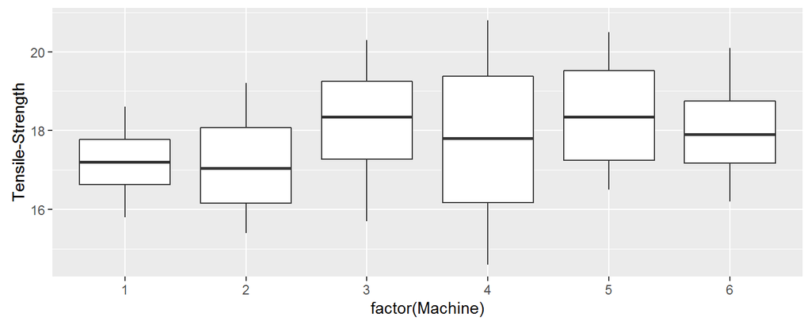

## ex 13.1 analysis

```r
summary(aov(`Tensile-Strength` ~ factor(Machine), seals))
```

```
##                 Df Sum Sq Mean Sq F value Pr(>F)
## factor(Machine)  5   5.34   1.068   0.307  0.902
## Residuals       18  62.64   3.480
```

## Exercise 13.2

"Hours of relief for people with fevers". \(k=5\) tablets with \(n=5\) subjects each.

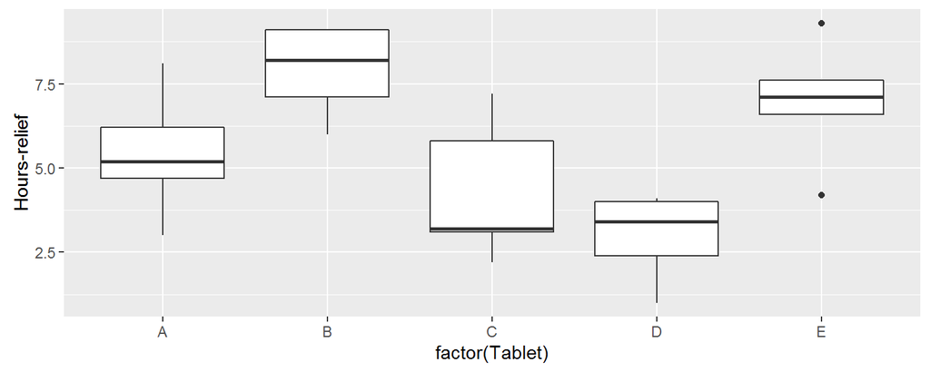

```
##                Df Sum Sq Mean Sq F value Pr(>F)
## factor(Tablet)  4  78.42  19.605   6.587 0.0015 **
## Residuals      20  59.53   2.977
## ---
## Signif. codes:  0 '***' 0.001 '**' 0.01 '*' 0.05 '.' 0.1 ' ' 1
```

## Relationship with other analyses

When \(k=2\) the usual analysis is done with a two-sample \(t\) test. The p-value obtained using the \(F\) approach will be *identical* to the one using the \(t\) test (equal variance assumption version).

The analyis is *identical* (mathematically) to the multiple regression with the factor variable coded into the required number of dummy variables.

Sadly the book chooses (which I have followed) to use \(k\) as the number of variables in a regression model as well as the number of levels for a factor. Of course, \(k\) levels translates into \(k-1\) dummy variables.

## Model assumptions

The model assumptions are the same as for the two-sample \(t\) test: equal variances, normal errors.

The way to assess the model assumptions is similar, but adjusted for \(k\) levels rather than just 2.

For normality, use a normal quantile plot of the "residuals" \(y_{ij} - {\overline{y}}_{i\cdot}\).

There is no good formal statistical test for equal variances. We'll use this heuristic. Calculate:\[\frac{\max_i s^2_i}{\min_i s^2_i}\]

## ANOVA equal variance assumption heuristic

Compare with:

- 9, when the residuals are normal *and* the experiment is balanced
- 4, when the residuals are non-normal *or* the experiment is (severely) unbalanced (but not both)
- 3, when the residuals are non-normal *and* the experiment is (severely) unbalanced

## Rubber seals assumptions check

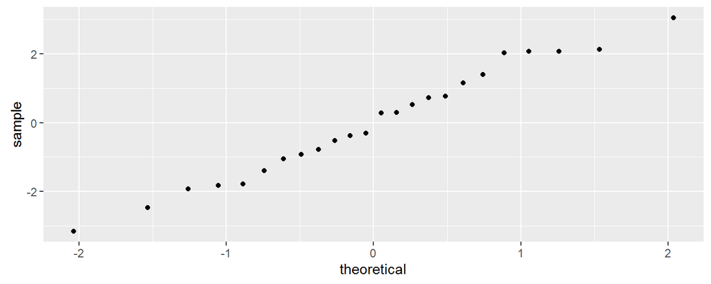

```
## Source: local data frame [6 x 2]
##
##   Machine Variance
##     (int)    (dbl)
## 1       1 1.366667
## 2       2 2.709167
## 3       3 3.769167
## 4       4 7.216667
## 5       5 3.155833
## 6       6 2.662500
```

## Multiple comparisons

The basic analysis does not give information about the most common follow-up question: which pairs of groups are different?

Naive approach: perform the \(k(k-1)/2\) two-sample \(t\) tests of the pairs that interest us.

Problems: Type I error, and bias.

Solution: perform *all* pairwise comparisons, holding them to a standard that controls for an overall "experiment-wise" error rate.

## Tukey's procedure

Works for balanced experiments: \(n_i = n\) for all \(i\)

Rather than comparing\[\frac{{\overline{y}}_{i\cdot} - {\overline{y}}_{j\cdot}}{\sqrt{2\cdot MSE/n}}\]with a \(t\) distribution, we'll compare it with a special purpose (wider) distributioncalled the "studentized range distribution", which is the distribution of:

\[\frac{\max_i {\overline{y}}_{i\cdot} - \min_j {\overline{y}}_{j\cdot}}{\sqrt{MSE/n}}\]

Distribution parameters: \(k\) and \(\nu = k(n-1)\)

## Tukey's procedure algorithm

This is classical hypothesis testing: fix \(\alpha\)

Perform the overall \(F\) test. If "accept", **stop**.

Find the \(\alpha\) upper-tail probability point \(q[\alpha,k,\nu]\) from the table.

Multiply it by \(\sqrt{MSE/n}\) to get the comparison threshold ("critical value")

Rank the \(y_{i\cdot}\) (low to high) and compare.

## Example: rubber seals

Done.

## Example: tablets

\(\alpha = 0.05\)

\(q(0.05, 5, 20) = 4.24\)

| Tablet | Mean |
| --- | --- |
| D | 2.98 |
| C | 4.30 |
| A | 5.44 |
| E | 6.96 |
| B | 7.90 |

```
##                Df Sum Sq Mean Sq F value Pr(>F)
## factor(Tablet)  4  78.42  19.605   6.587 0.0015 **
## Residuals      20  59.53   2.977
## ---
## Signif. codes:  0 '***' 0.001 '**' 0.01 '*' 0.05 '.' 0.1 ' ' 1
```